# COVID

Sorabh Kaila

2024-07-12

```r
#install.packages("tidyverse")
library(tidyverse)
```

```r
library(lubridate)
library(ggplot2)
```

# Conduct an analysis of covid cases and deaths for both US and Global to understand the trends and idnentify Countries/Regions with high death rates.

## Gather data (Josh Hopkins Github Site)

### url for the site

```r
url_in= "https://raw.githubusercontent.com/CSSEGISandData/COVID-19/master/csse_covid_19_data/csse_covid_19_time_series/"
```

### Import different datasets…us cases, us deaths, global cases & global deaths.

```r
file_names = c("time_series_covid19_confirmed_US.csv",
  "time_series_covid19_confirmed_global.csv",
  "time_series_covid19_deaths_US.csv",
  "time_series_covid19_deaths_global.csv")

urls = str_c(url_in,file_names)
urls
```

```
## [1] "https://raw.githubusercontent.com/CSSEGISandData/COVID-19/master/csse_covid_19_data/csse_covid_19_time_series/time_series_covid19_confirmed_US.csv"
## [2] "https://raw.githubusercontent.com/CSSEGISandData/COVID-19/master/csse_covid_19_data/csse_covid_19_time_series/time_series_covid19_confirmed_global.csv"
## [3] "https://raw.githubusercontent.com/CSSEGISandData/COVID-19/master/csse_covid_19_data/csse_covid_19_time_series/time_series_covid19_deaths_US.csv"
## [4] "https://raw.githubusercontent.com/CSSEGISandData/COVID-19/master/csse_covid_19_data/csse_covid_19_time_series/time_series_covid19_deaths_global.csv"
```

```r
global_cases = read_csv(urls[2])
global_deaths = read_csv(urls[4])
us_cases = read_csv(urls[1])
us_deaths = read_csv(urls[3])
```

## Clean and Transform Global Data

### View Global cases and clean data…delete columns not needed (Lat and Long). Pivot date into 1 column.

```r
head(global_cases)
```

```
## # A tibble: 6 × 1,147
##   `Province/State` `Country/Region`   Lat  Long `1/22/20` `1/23/20` `1/24/20`
##   <chr>            <chr>            <dbl> <dbl>     <dbl>     <dbl>     <dbl>
## 1 <NA>             Afghanistan       33.9 67.7          0         0         0
## 2 <NA>             Albania           41.2 20.2          0         0         0
## 3 <NA>             Algeria           28.0  1.66         0         0         0
## 4 <NA>             Andorra           42.5  1.52         0         0         0
## 5 <NA>             Angola           -11.2 17.9          0         0         0
## 6 <NA>             Antarctica       -71.9 23.3          0         0         0
## # ℹ 1,140 more variables: `1/25/20` <dbl>, `1/26/20` <dbl>, `1/27/20` <dbl>,
## #   `1/28/20` <dbl>, `1/29/20` <dbl>, `1/30/20` <dbl>, `1/31/20` <dbl>,
## #   `2/1/20` <dbl>, `2/2/20` <dbl>, `2/3/20` <dbl>, `2/4/20` <dbl>,
## #   `2/5/20` <dbl>, `2/6/20` <dbl>, `2/7/20` <dbl>, `2/8/20` <dbl>,
## #   `2/9/20` <dbl>, `2/10/20` <dbl>, `2/11/20` <dbl>, `2/12/20` <dbl>,
## #   `2/13/20` <dbl>, `2/14/20` <dbl>, `2/15/20` <dbl>, `2/16/20` <dbl>,
## #   `2/17/20` <dbl>, `2/18/20` <dbl>, `2/19/20` <dbl>, `2/20/20` <dbl>, …
```

```r
global_cases = subset(global_cases,select = -c(Lat,Long))
global_cases= global_cases%>%
  pivot_longer(cols = -c("Province/State","Country/Region"),
               names_to="date",values_to="cases")
```

### View Global deaths and clean data…delete columns not needed (Lat and Long). Pivot date into 1 column.

```r
head(global_deaths)
```

```
## # A tibble: 6 × 1,147
##   `Province/State` `Country/Region`   Lat  Long `1/22/20` `1/23/20` `1/24/20`
##   <chr>            <chr>            <dbl> <dbl>     <dbl>     <dbl>     <dbl>
## 1 <NA>             Afghanistan       33.9 67.7          0         0         0
## 2 <NA>             Albania           41.2 20.2          0         0         0
## 3 <NA>             Algeria           28.0  1.66         0         0         0
## 4 <NA>             Andorra           42.5  1.52         0         0         0
## 5 <NA>             Angola           -11.2 17.9          0         0         0
## 6 <NA>             Antarctica       -71.9 23.3          0         0         0
## # ℹ 1,140 more variables: `1/25/20` <dbl>, `1/26/20` <dbl>, `1/27/20` <dbl>,
## #   `1/28/20` <dbl>, `1/29/20` <dbl>, `1/30/20` <dbl>, `1/31/20` <dbl>,
## #   `2/1/20` <dbl>, `2/2/20` <dbl>, `2/3/20` <dbl>, `2/4/20` <dbl>,
## #   `2/5/20` <dbl>, `2/6/20` <dbl>, `2/7/20` <dbl>, `2/8/20` <dbl>,
## #   `2/9/20` <dbl>, `2/10/20` <dbl>, `2/11/20` <dbl>, `2/12/20` <dbl>,
## #   `2/13/20` <dbl>, `2/14/20` <dbl>, `2/15/20` <dbl>, `2/16/20` <dbl>,
## #   `2/17/20` <dbl>, `2/18/20` <dbl>, `2/19/20` <dbl>, `2/20/20` <dbl>, …
```

```r
global_deaths = subset(global_deaths,select = -c(Lat,Long))
global_deaths= global_deaths%>%
  pivot_longer(cols = -c("Province/State","Country/Region"),
               names_to="date",values_to="deaths")
```

### Combine global cases and deaths in 1 dataset and change date format to date

```r
library(lubridate)
global = full_join(global_cases,global_deaths,by = c("Province/State","Country/Region","date"))

global = global%>%mutate(global, date = mdy(date))

head(global)
```

```
## # A tibble: 6 × 5
##   `Province/State` `Country/Region` date       cases deaths
##   <chr>            <chr>            <date>     <dbl>  <dbl>
## 1 <NA>             Afghanistan      2020-01-22     0      0
## 2 <NA>             Afghanistan      2020-01-23     0      0
## 3 <NA>             Afghanistan      2020-01-24     0      0
## 4 <NA>             Afghanistan      2020-01-25     0      0
## 5 <NA>             Afghanistan      2020-01-26     0      0
## 6 <NA>             Afghanistan      2020-01-27     0      0
```

```r
summary(global)
```

```
##  Province/State     Country/Region          date                cases
##  Length:330327      Length:330327      Min.   :2020-01-22   Min.   :        0
##  Class :character   Class :character   1st Qu.:2020-11-02   1st Qu.:      680
##  Mode  :character   Mode  :character   Median :2021-08-15   Median :    14429
##                                        Mean   :2021-08-15   Mean   :   959384
##                                        3rd Qu.:2022-05-28   3rd Qu.:   228517
##                                        Max.   :2023-03-09   Max.   :103802702
##      deaths
##  Min.   :      0
##  1st Qu.:      3
##  Median :    150
##  Mean   :  13380
##  3rd Qu.:   3032
##  Max.   :1123836
```

### include only data with cases>0

```r
global = global%>%filter(cases>0)
summary(global)
```

```
##  Province/State     Country/Region          date                cases
##  Length:306827      Length:306827      Min.   :2020-01-22   Min.   :        1
##  Class :character   Class :character   1st Qu.:2020-12-12   1st Qu.:     1316
##  Mode  :character   Mode  :character   Median :2021-09-16   Median :    20365
##                                        Mean   :2021-09-11   Mean   :  1032863
##                                        3rd Qu.:2022-06-15   3rd Qu.:   271281
##                                        Max.   :2023-03-09   Max.   :103802702
##      deaths
##  Min.   :      0
##  1st Qu.:      7
##  Median :    214
##  Mean   :  14405
##  3rd Qu.:   3665
##  Max.   :1123836
```

### Look at outliers….All these cases seem to be valid so leave them in the dataset.

```r
global%>%filter(cases>2800000)
```

```
## # A tibble: 20,984 × 5
##    `Province/State` `Country/Region` date         cases deaths
##    <chr>            <chr>            <date>       <dbl>  <dbl>
##  1 <NA>             Argentina        2021-04-23 2824652  61176
##  2 <NA>             Argentina        2021-04-24 2845872  61474
##  3 <NA>             Argentina        2021-04-25 2860884  61644
##  4 <NA>             Argentina        2021-04-26 2879677  62087
##  5 <NA>             Argentina        2021-04-27 2905172  62599
##  6 <NA>             Argentina        2021-04-28 2928890  62947
##  7 <NA>             Argentina        2021-04-29 2954943  63508
##  8 <NA>             Argentina        2021-04-30 2977363  63865
##  9 <NA>             Argentina        2021-05-01 2993865  64096
## 10 <NA>             Argentina        2021-05-02 3005259  64252
## # ℹ 20,974 more rows
```

## Clean and Transform US Data

### US Dataset: Remove columns not needed, pivot date into 1 column and combine cases & deaths into 1 dataset.

```r
us_cases = subset(us_cases,select=-c(UID,iso2,iso3,code3,FIPS, Lat, Long_))
us_deaths = subset(us_deaths,select=-c(UID,iso2,iso3,code3,FIPS, Lat, Long_))
us_cases= us_cases%>%
  pivot_longer(cols = -c(Admin2:Combined_Key),
               names_to="date",values_to="cases")
us_deaths= us_deaths%>%
  pivot_longer(cols = -c(Admin2:Population),
               names_to="date",values_to="deaths")

us = full_join(us_cases,us_deaths,by = c("Admin2","Province_State","Country_Region","Combined_Key","date"))

us = us%>%mutate(us, date = mdy(date))
summary(us)
```

```
##     Admin2          Province_State     Country_Region     Combined_Key
##  Length:3819906     Length:3819906     Length:3819906     Length:3819906
##  Class :character   Class :character   Class :character   Class :character
##  Mode  :character   Mode  :character   Mode  :character   Mode  :character
##
##
##
##       date                cases           Population           deaths
##  Min.   :2020-01-22   Min.   :  -3073   Min.   :       0   Min.   :  -82.0
##  1st Qu.:2020-11-02   1st Qu.:    330   1st Qu.:    9917   1st Qu.:    4.0
##  Median :2021-08-15   Median :   2272   Median :   24892   Median :   37.0
##  Mean   :2021-08-15   Mean   :  14088   Mean   :   99604   Mean   :  186.9
##  3rd Qu.:2022-05-28   3rd Qu.:   8159   3rd Qu.:   64979   3rd Qu.:  122.0
##  Max.   :2023-03-09   Max.   :3710586   Max.   :10039107   Max.   :35545.0
```

## Add columns to Global dataset so that it is in the same format as US data.

### Add combined key to Global dataset

```r
colnames(global) = c("Province_State","Country_Region","date","cases","deaths")

global = global%>%unite("Combined_Key",c(Province_State,Country_Region),sep=",",na.rm=TRUE,remove=FALSE)
```

### Add global population to global dataset

```r
pop_url = "https://raw.githubusercontent.com/CSSEGISandData/COVID-19/master/csse_covid_19_data/UID_ISO_FIPS_LookUp_Table.csv"

pop = read_csv(pop_url)
pop = subset(pop,select = -c(UID:FIPS))
pop = subset(pop,select = -c(Lat,Long_,Combined_Key))
global = left_join(global,pop,by =c("Province_State","Country_Region"))
```

## Group US data by State and by Date to analyze trends.

### Group US data by State. Add death per mil metric.

```r
us_state = us %>% group_by(Province_State,Country_Region,date) %>%
summarize(cases=sum(cases),deaths=sum(deaths),Population = sum(Population)) %>% mutate (deaths_per_mil = deaths*1000000/Population) %>% select(Province_State,Country_Region,date,cases,deaths,deaths_per_mil,Population) %>% ungroup()
```

### Group US data by date. Add deaths_per million metric.

```r
us_total = us_state %>% group_by(Country_Region,date) %>%
summarize(cases=sum(cases),deaths=sum(deaths),Population = sum(Population)) %>% mutate (deaths_per_mil = deaths*1000000/Population) %>% select(Country_Region,date,cases,deaths,deaths_per_mil,Population) %>% ungroup()
tail(us_total)
```

```
## # A tibble: 6 × 6
##   Country_Region date           cases  deaths deaths_per_mil Population
##   <chr>          <date>         <dbl>   <dbl>          <dbl>      <dbl>
## 1 US             2023-03-04 103650837 1122172          3371.  332875137
## 2 US             2023-03-05 103646975 1122134          3371.  332875137
## 3 US             2023-03-06 103655539 1122181          3371.  332875137
## 4 US             2023-03-07 103690910 1122516          3372.  332875137
## 5 US             2023-03-08 103755771 1123246          3374.  332875137
## 6 US             2023-03-09 103802702 1123836          3376.  332875137
```

## Visualize Data:

### Cases and deaths trend by date

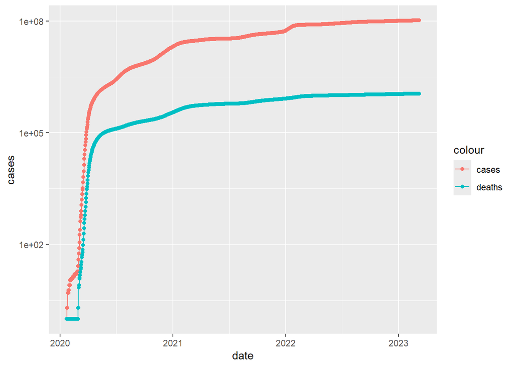

```r
us_total %>%
  filter(cases>0) %>%
  ggplot(aes(x=date, y = cases))+
  geom_line(aes(color="cases"))+
  geom_point(aes(color="cases"))+
  geom_line(aes(y=deaths, color="deaths"))+
  geom_point(aes(y=deaths, color="deaths"))+
  scale_y_log10()
```

### Visualize data for NY only

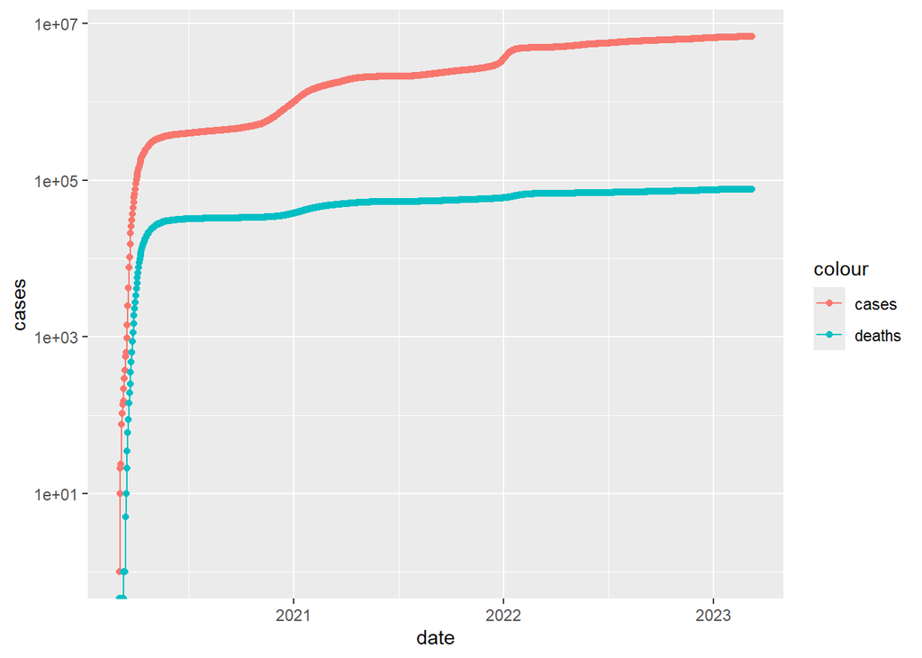

```r
us_state %>%
  filter(Province_State == "New York") %>%
  filter(cases>0) %>%
  ggplot(aes(x=date, y = cases))+
  geom_line(aes(color="cases"))+
  geom_point(aes(color="cases"))+
  geom_line(aes(y=deaths, color="deaths"))+
  geom_point(aes(y=deaths, color="deaths"))+
  scale_y_log10()
```

## Analyze Data

### Look at the max of us cases and deaths

```r
max(us_total$date)
```

```
## [1] "2023-03-09"
```

```r
max(us_total$cases)
```

```
## [1] 103802702
```

```r
max(us_total$deaths)
```

```
## [1] 1123836
```

### Add…new cases and new deaths

```r
us_state = us_state %>% mutate(new_cases = cases-lag(cases))
us_state = us_state %>% mutate(new_deaths = deaths-lag(deaths))
us_total = us_total %>% mutate(new_cases = cases-lag(cases))
us_total = us_total %>% mutate(new_deaths = deaths-lag(deaths))
tail(us_total %>% select(new_cases,new_deaths,everything()))
```

```
## # A tibble: 6 × 8
##   new_cases new_deaths Country_Region date           cases deaths deaths_per_mil
##       <dbl>      <dbl> <chr>          <date>         <dbl>  <dbl>          <dbl>
## 1      2147          7 US             2023-03-04 103650837 1.12e6          3371.
## 2     -3862        -38 US             2023-03-05 103646975 1.12e6          3371.
## 3      8564         47 US             2023-03-06 103655539 1.12e6          3371.
## 4     35371        335 US             2023-03-07 103690910 1.12e6          3372.
## 5     64861        730 US             2023-03-08 103755771 1.12e6          3374.
## 6     46931        590 US             2023-03-09 103802702 1.12e6          3376.
## # ℹ 1 more variable: Population <dbl>
```

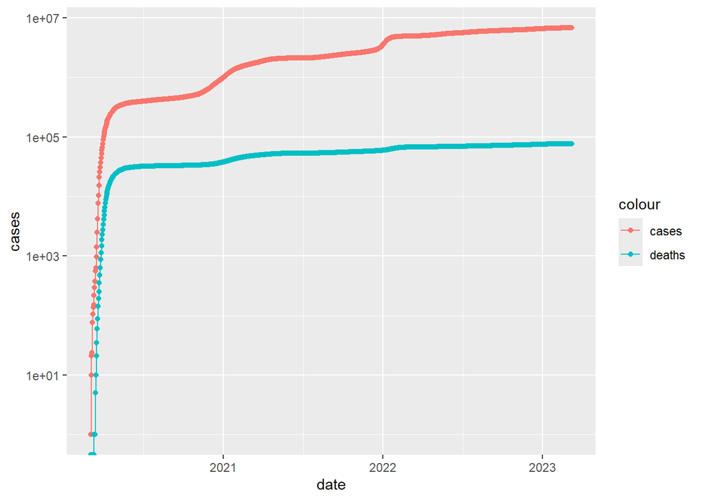

```r
us_state %>%
filter(Province_State == "New York") %>%
filter(new_cases>0) %>%
ggplot(aes(x=date, y = cases))+
geom_line(aes(color="cases"))+
geom_point(aes(color="cases"))+
geom_line(aes(y=deaths, color="deaths"))+
geom_point(aes(y=deaths, color="deaths"))+
scale_y_log10()
```

### Analyze data by State

```r
us_state_total = us_state %>%
  group_by(Province_State) %>%
summarize(cases = max(cases),deaths=max(deaths),Population=max(Population),
          cases_per_thousand = cases*1000/Population,
          deaths_per_thousand = deaths*1000/Population) %>%
  filter(cases>0,Population>0)
```

### States with lowest death rate & max death rate

```r
us_state_total %>% slice_min (deaths_per_thousand,n=10) %>%
  select(deaths_per_thousand,everything())
```

```
## # A tibble: 10 × 6
##    deaths_per_thousand Province_State             cases deaths Population
##                  <dbl> <chr>                      <dbl>  <dbl>      <dbl>
##  1               0.611 American Samoa              8320     34      55641
##  2               0.744 Northern Mariana Islands   13666     41      55144
##  3               1.21  Virgin Islands             24813    130     107268
##  4               1.30  Hawaii                    380608   1841    1415872
##  5               1.49  Vermont                   152618    929     623989
##  6               1.55  Puerto Rico              1101469   5823    3754939
##  7               1.65  Utah                     1090346   5298    3205958
##  8               2.01  Alaska                    307655   1486     740995
##  9               2.03  District of Columbia      177945   1432     705749
## 10               2.06  Washington               1928913  15683    7614893
## # ℹ 1 more variable: cases_per_thousand <dbl>
```

```r
us_state_total %>% slice_max (deaths_per_thousand,n=10) %>%
  select(deaths_per_thousand,everything())
```

```
## # A tibble: 10 × 6
##    deaths_per_thousand Province_State   cases deaths Population
##                  <dbl> <chr>            <dbl>  <dbl>      <dbl>
##  1                4.55 Arizona        2443514  33102    7278717
##  2                4.54 Oklahoma       1290929  17972    3956971
##  3                4.49 Mississippi     990756  13370    2976149
##  4                4.44 West Virginia   642760   7960    1792147
##  5                4.32 New Mexico      670929   9061    2096829
##  6                4.31 Arkansas       1006883  13020    3017804
##  7                4.29 Alabama        1644533  21032    4903185
##  8                4.28 Tennessee      2515130  29263    6829174
##  9                4.23 Michigan       3064125  42205    9986857
## 10                4.06 Kentucky       1718471  18130    4467673
## # ℹ 1 more variable: cases_per_thousand <dbl>
```

## Modeling Data

### Build a linear model to predict deaths per thousand based on cases per thousand. There is a lot of variance between predicted deaths and actual deaths.

```r
mod = lm(deaths_per_thousand~cases_per_thousand,data = us_state_total)
summary(mod)
```

```
##
## Call:
## lm(formula = deaths_per_thousand ~ cases_per_thousand, data = us_state_total)
##
## Residuals:
##     Min      1Q  Median      3Q     Max
## -2.3352 -0.5978  0.1491  0.6535  1.2086
##
## Coefficients:
##                    Estimate Std. Error t value Pr(>|t|)
## (Intercept)        -0.36167    0.72480  -0.499     0.62
## cases_per_thousand  0.01133    0.00232   4.881 9.76e-06 ***
## ---
## Signif. codes:  0 '***' 0.001 '**' 0.01 '*' 0.05 '.' 0.1 ' ' 1
##
## Residual standard error: 0.8615 on 54 degrees of freedom
## Multiple R-squared:  0.3061, Adjusted R-squared:  0.2933
## F-statistic: 23.82 on 1 and 54 DF,  p-value: 9.763e-06
```

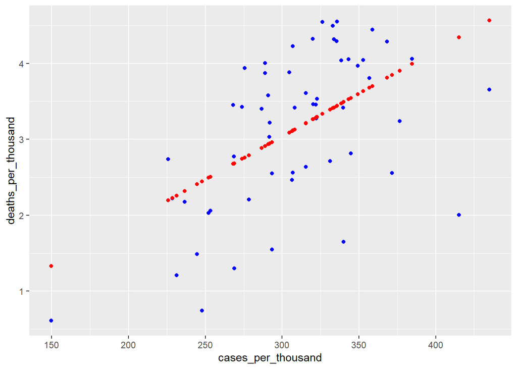

```r
us_state_total_pred = us_state_total %>% mutate(pred = predict(mod))

us_state_total_pred %>% ggplot() + geom_point(aes(x = cases_per_thousand,y=deaths_per_thousand),color="blue")+
  geom_point(aes(x = cases_per_thousand,y=pred),color="red")
```

## Analyze Global Data

### Group global data by country and add new deaths and new cases

```r
global_country = global %>% group_by(Country_Region,date) %>%
summarize(cases=sum(cases),deaths=sum(deaths),Population = sum(Population)) %>% mutate (deaths_per_mil = deaths*1000000/Population) %>% select(Country_Region,date,cases,deaths,deaths_per_mil,Population) %>% ungroup()
global_country
```

```
## # A tibble: 214,113 × 6
##    Country_Region date       cases deaths deaths_per_mil Population
##    <chr>          <date>     <dbl>  <dbl>          <dbl>      <dbl>
##  1 Afghanistan    2020-02-24     5      0              0   38928341
##  2 Afghanistan    2020-02-25     5      0              0   38928341
##  3 Afghanistan    2020-02-26     5      0              0   38928341
##  4 Afghanistan    2020-02-27     5      0              0   38928341
##  5 Afghanistan    2020-02-28     5      0              0   38928341
##  6 Afghanistan    2020-02-29     5      0              0   38928341
##  7 Afghanistan    2020-03-01     5      0              0   38928341
##  8 Afghanistan    2020-03-02     5      0              0   38928341
##  9 Afghanistan    2020-03-03     5      0              0   38928341
## 10 Afghanistan    2020-03-04     5      0              0   38928341
## # ℹ 214,103 more rows
```

```r
global_country = global_country %>% mutate(new_cases = cases-lag(cases))
global_country = global_country %>% mutate(new_deaths = deaths-lag(deaths))
global_country = global_country %>% mutate(new_cases = cases-lag(cases))
global_country = global_country %>% mutate(new_deaths = deaths-lag(deaths))
tail(global_country %>% select(new_cases,new_deaths,everything()))
```

```
## # A tibble: 6 × 8
##   new_cases new_deaths Country_Region date        cases deaths deaths_per_mil
##       <dbl>      <dbl> <chr>          <date>      <dbl>  <dbl>          <dbl>
## 1         0          0 Zimbabwe       2023-03-04 264127   5668           381.
## 2         0          0 Zimbabwe       2023-03-05 264127   5668           381.
## 3         0          0 Zimbabwe       2023-03-06 264127   5668           381.
## 4         0          0 Zimbabwe       2023-03-07 264127   5668           381.
## 5       149          3 Zimbabwe       2023-03-08 264276   5671           382.
## 6         0          0 Zimbabwe       2023-03-09 264276   5671           382.
## # ℹ 1 more variable: Population <dbl>
```

### Create a dataset for totals by Country

```r
global_country_total = global_country %>%
  group_by(Country_Region) %>%
summarize(cases = max(cases),deaths=max(deaths),Population=max(Population),
          cases_per_thousand = cases*1000/Population,
          deaths_per_thousand = deaths*1000/Population) %>%
  filter(cases>0,Population>0)
tail(global_country_total)
```

```
## # A tibble: 6 × 6
##   Country_Region  cases deaths Population cases_per_thousand deaths_per_thousand
##   <chr>           <dbl>  <dbl>      <dbl>              <dbl>               <dbl>
## 1 Venezuela      5.52e5   5854   28435943             19.4                0.206
## 2 Vietnam        1.15e7  43186   97338583            118.                 0.444
## 3 West Bank and… 7.03e5   5708    5101416            138.                 1.12
## 4 Yemen          1.19e4   2159   29825968              0.400              0.0724
## 5 Zambia         3.43e5   4057   18383956             18.7                0.221
## 6 Zimbabwe       2.64e5   5671   14862927             17.8                0.382
```

### Countries with maximum deaths…Peru, Bulgaria and Hungary have the max deaths_per_thousand of population

```r
global_country_total %>% slice_max (deaths_per_thousand,n=10) %>%
  select(deaths_per_thousand,everything())
```

```
## # A tibble: 10 × 6
##    deaths_per_thousand Country_Region           cases deaths Population
##                  <dbl> <chr>                    <dbl>  <dbl>      <dbl>
##  1                6.66 Peru                   4487553 219539   32971846
##  2                5.50 Bulgaria               1297523  38228    6948445
##  3                5.05 Hungary                2196804  48762    9660350
##  4                4.96 Bosnia and Herzegovina  401729  16280    3280815
##  5                4.64 North Macedonia         346852   9662    2083380
##  6                4.47 Montenegro              288808   2808     628062
##  7                4.38 Croatia                1269326  17987    4105268
##  8                4.25 Georgia                1827537  16971    3989175
##  9                3.97 Czechia                4618256  42491   10708982
## 10                3.87 Slovakia               2667551  21035    5434712
## # ℹ 1 more variable: cases_per_thousand <dbl>
```

### Countries with minimum deaths…there seems to be reporting issues in the top 3 countries…

### Population is too low for Holy See and Tuvalu so lets discard these. N. Korea shows only 1 case and 6 deaths so defintely there seems to be a reporting issue…Need to understand further

```r
global_country_total %>% slice_min (deaths_per_thousand,n=10) %>%
  select(deaths_per_thousand,everything())
```

```
## # A tibble: 10 × 6
##    deaths_per_thousand Country_Region cases deaths Population cases_per_thousand
##                  <dbl> <chr>          <dbl>  <dbl>      <dbl>              <dbl>
##  1            0        Holy See          29      0        809         35.8
##  2            0        Tuvalu          2828      0      11792        240.
##  3            0.000233 Korea, North       1      6   25778815          0.0000388
##  4            0.00320  Burundi        53631     38   11890781          4.51
##  5            0.0118   Chad            7679    194   16425859          0.467
##  6            0.0123   South Sudan    18368    138   11193729          1.64
##  7            0.0130   Niger           9508    315   24206636          0.393
##  8            0.0131   Tajikistan     17786    125    9537642          1.86
##  9            0.0134   Benin          27999    163   12123198          2.31
## 10            0.0142   Tanzania       42906    846   59734213          0.718
```

## Visualize Data

### Top 20 Countries based on death_per_thousand of population

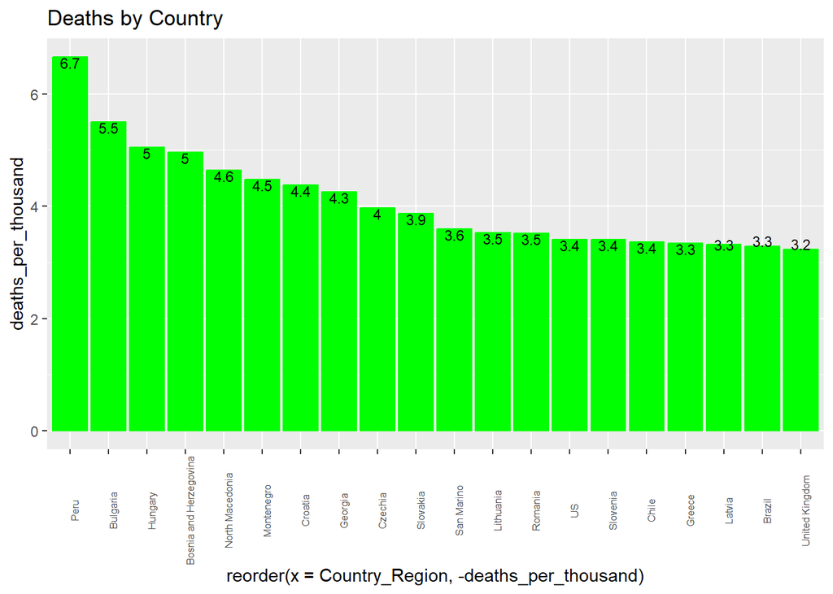

```r
global_country_top20 = global_country_total %>% slice_max(deaths_per_thousand,n=20) %>% arrange(desc(deaths_per_thousand))

global_country_top20 %>%
ggplot(aes(reorder(x=Country_Region,-deaths_per_thousand),y=deaths_per_thousand))+
  geom_bar(position='dodge',stat = 'identity',color='green',fill='green')+
  ggtitle("Deaths by Country")+
  geom_text(aes(label = round(deaths_per_thousand,1)),size=3,color="black",vjust="inward")+
  theme(axis.text.x = element_text(size=6, angle = 90))
```

### Bottom 20 countries based on death per thousand of population

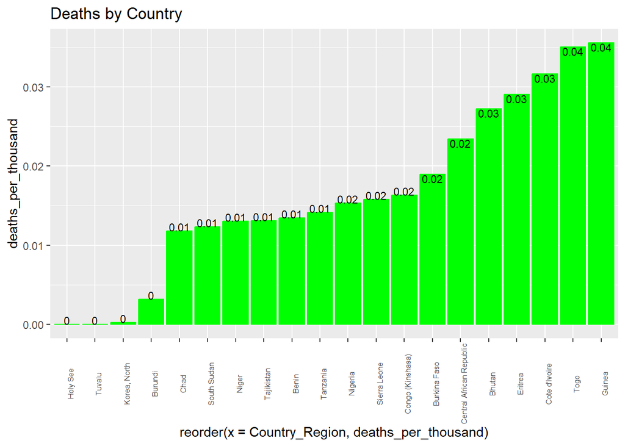

```r
global_country_bottom20 = global_country_total %>% slice_min(deaths_per_thousand,n=20) %>% arrange(desc(deaths_per_thousand))

global_country_bottom20 %>%
ggplot(aes(reorder(x=Country_Region,deaths_per_thousand),y=deaths_per_thousand))+
  geom_bar(position='dodge',stat = 'identity',color='green',fill='green')+
  ggtitle("Deaths by Country")+
  geom_text(aes(label = round(deaths_per_thousand,2)),size=3,color="black",vjust="inward")+
  theme(axis.text.x = element_text(size=6, angle = 90))
```

### Visualize data for countries with largest population. This has some interesting observations. US has highest deaths_per thousand and India, Indonesia and Pakisatan are extremely low on the list. Looks like China data is missing from the global dataset.

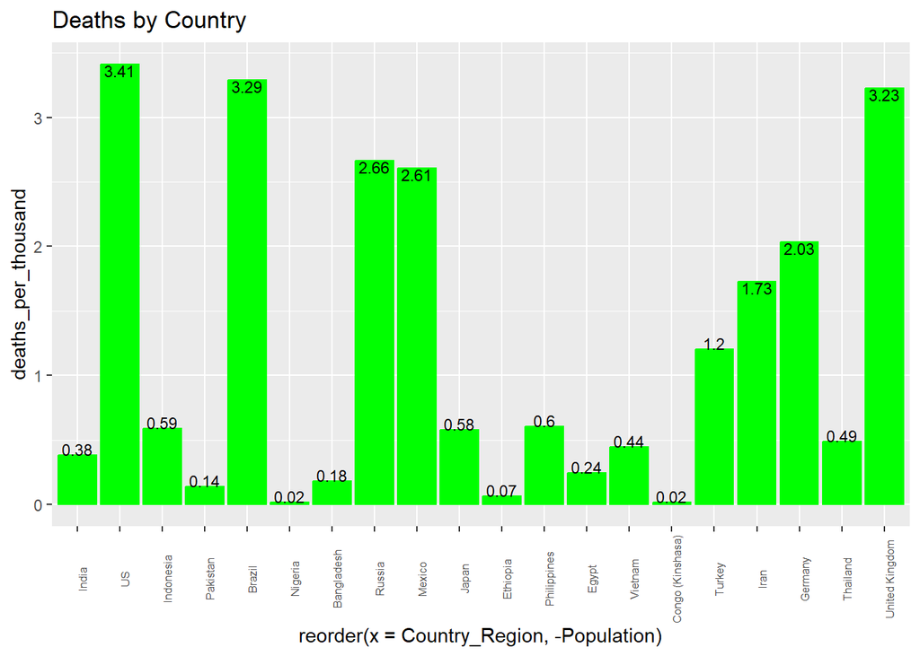

```r
global_country_top_pop = global_country_total %>% slice_max(Population,n=20)

global_country_top_pop %>%
ggplot(aes(reorder(x=Country_Region,-Population),y=deaths_per_thousand))+
  geom_bar(position='dodge',stat = 'identity',color='green',fill='green')+
  ggtitle("Deaths by Country")+
  geom_text(aes(label = round(deaths_per_thousand,2)),size=3,color="black",vjust="inward")+
  theme(axis.text.x = element_text(size=6, angle = 90))
```

## Data Model

### Build a linear model for global data

```r
mod2 = lm(deaths_per_thousand~cases_per_thousand,data = global_country_total)
summary(mod2)
```

```
##
## Call:
## lm(formula = deaths_per_thousand ~ cases_per_thousand, data = global_country_total)
##
## Residuals:
##     Min      1Q  Median      3Q     Max
## -2.4069 -0.6090 -0.3898  0.4689  5.5423
##
## Coefficients:
##                     Estimate Std. Error t value Pr(>|t|)
## (Intercept)        0.6277935  0.1116605   5.622 6.57e-08 ***
## cases_per_thousand 0.0035877  0.0004393   8.167 4.13e-14 ***
## ---
## Signif. codes:  0 '***' 0.001 '**' 0.01 '*' 0.05 '.' 0.1 ' ' 1
##
## Residual standard error: 1.151 on 192 degrees of freedom
## Multiple R-squared:  0.2578, Adjusted R-squared:  0.254
## F-statistic:  66.7 on 1 and 192 DF,  p-value: 4.127e-14
```

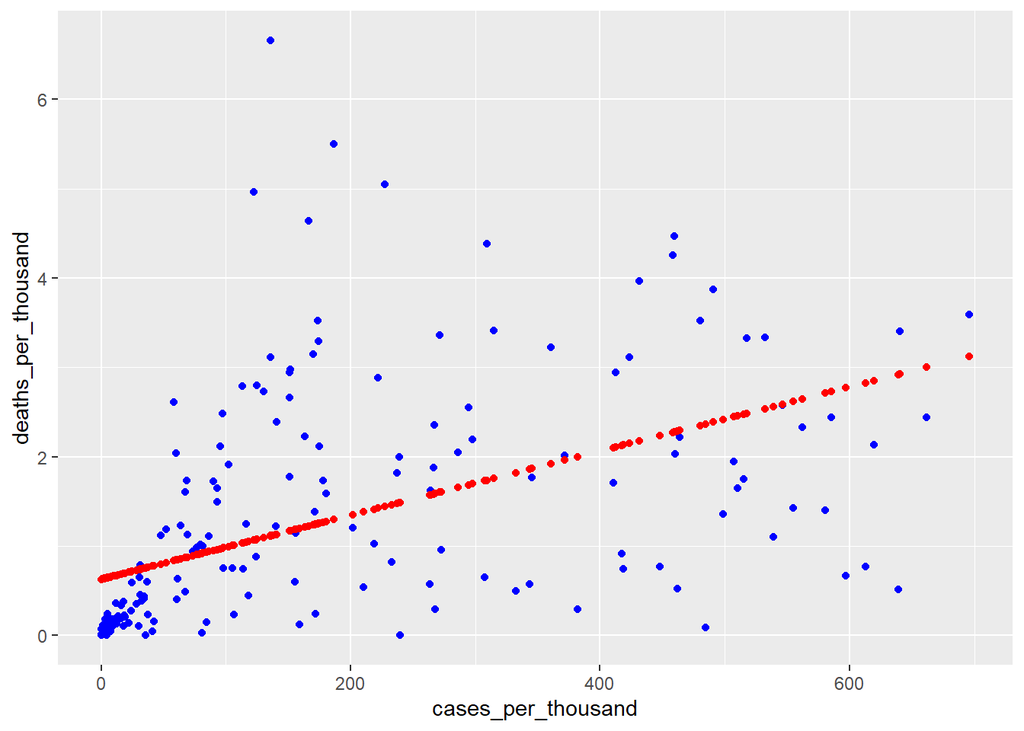

```r
global_country_total_pred = global_country_total %>% mutate(pred = predict(mod2))

global_country_total_pred %>% ggplot() + geom_point(aes(x = cases_per_thousand,y=deaths_per_thousand),color="blue")+
  geom_point(aes(x = cases_per_thousand,y=pred),color="red")
```

## Bias in the data

### Based on the initial analysis there seems to be a lot of variance between Countries in cases per thousand and deaths per thousand. There may be bias in the measurement system of different countries.

## Conclusion

### US: States like Utah, Puerto Rico and Vermont have a very low number of death_per_thousand of population compared to Arizona, Oklahom, Mississippi. Need to understand what is causing the variance and hopefully replicate best practices to reduce the overall deaths due to Covid for US.

### When we look at global data, need to understand why US has a much higher death_per_thousand of population ratio compared to some other countries with high population like India, Indonesia, Pakistan etc.

### Investigate what factors other than cases have an impact on deaths due to Covid so we can reduce the number of deaths.